# Time series - Predict the evolution of the flu

15/01/2019 - Based on a lab for Telecom Paris

In this tutorial, we will analyse the evolution of the flu in France over 4 years. The data is produced by [OpenHealth](https://www.openhealth.fr/) ([download csv](https://www.openhealth.fr/publicFiles/Openhealth_S-Grippal.csv)).  
First, we will **explore the data**, which is a time series. Then, we will **study the periodicity** of flu episodes. To finish, we will **predict the tendency** of the flu over a year.

```python
import pandas as pd
import numpy as np
import matplotlib.pyplot as plt
from pandas.plotting import register_matplotlib_converters
register_matplotlib_converters()
```

## Data cleaning

Load and prepare the data:

```python
df = pd.read_csv("data/OpenhealthS-Grippal.csv", sep=";")
df = df.drop(["IAS_lisse", "Incidence_Sentinelles"], axis=1)
df.rename(columns={'PERIODE': 'period'}, inplace=True)
# Change data types
df['period'] = pd.to_datetime(df['period'])
df['IAS_brut'] = pd.to_numeric(df['IAS_brut'].str.replace(",", "."), errors="coerce")
df.head()
```

|  | period | IAS_brut |
| --- | --- | --- |
| 0 | 2009-07-01 | 1.7 |
| 1 | 2009-07-02 | 3.4 |
| 2 | 2009-07-03 | 2.1 |
| 3 | 2009-07-04 | 1.3 |
| 4 | 2009-07-05 | 14.2 |

Display dates, frequency and statistics:

```python
print("Start date:", df["period"].min())
print("End date:", df["period"].max())
print("Duration between those dates:", df["period"].max() - df["period"].min())
print("Number of days in the dataset:", df["period"].count())
df.describe()
```

```
Start date: 2009-07-01 00:00:00
End date: 2014-04-17 00:00:00
Duration between those dates: 1751 days 00:00:00
Number of days in the dataset: 1752
```

|  | IAS_brut |
| --- | --- |
| count | 1752.000000 |
| mean | 315.234018 |
| std | 2745.958062 |
| min | 0.000000 |
| 25% | 1.300000 |
| 50% | 3.800000 |
| 75% | 23.100000 |
| max | 71851.800000 |

We will replace the values 0 by the meaning of the value by the previous value and the following one.

```python
print("Number of values equal to 0:", df["IAS_brut"][df["IAS_brut"] == 0].count())
# Replace 0 by Nan
df["IAS_brut"].replace(0, np.nan, inplace=True)
# Interpolate Nan values
df["IAS_brut"] = df["IAS_brut"].interpolate(method='linear')
```

```
Number of values equal to 0: 8
```

## Data exploration

Time series display:

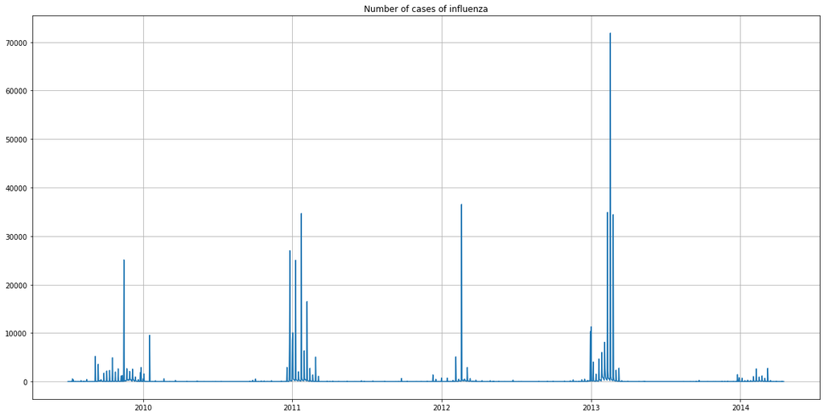

```python
plt.figure(figsize=(20,10))
plt.plot(df["period"], df["IAS_brut"])
plt.grid()
plt.title("Number of cases of influenza")
plt.show()
```

The graph represents the number of cases of influenza detected per day, over 5 years.  
There was a strong peak in 2013. It appears in the [press](https://www.pourquoidocteur.fr/Articles/Question-d-actu/3878-Grippe-2013-l-epidemie-la-plus-longue-depuis-30-ans) that this was the longest epidemic for 30 years.  
It seems that there were few cases in 2014, but this is explained by the fact that the data stopped in April 2014.

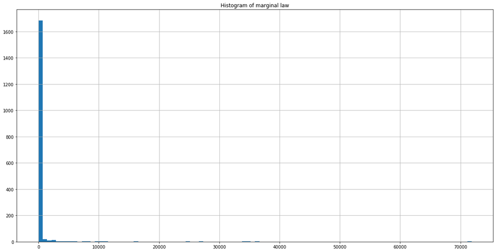

```python
plt.figure(figsize=(20,10))
plt.hist(df["IAS_brut"], 100)
plt.grid()
plt.title("Histogram of marginal law")
plt.show()
```

The histogram shows that most of the days, there are few cases of influenza.

In order to better visualize the variations, we will apply the natural logarithm to the data.

```python
df["IAS_brut"] = np.log(df["IAS_brut"])
```

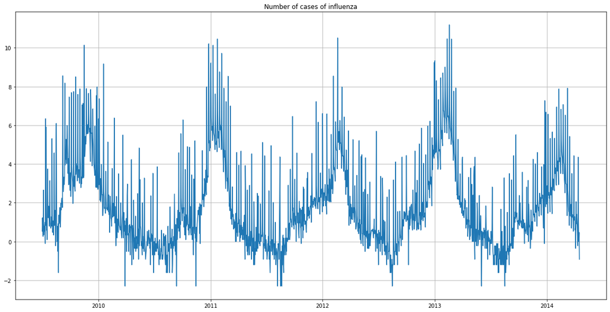

```python
plt.figure(figsize=(20,10))
plt.plot(df["period"], df["IAS_brut"])
plt.grid()
plt.title("Number of cases of influenza")
plt.show()
```

**We now notice that the number of cases of influenza is cyclical. It follows a similar pattern from year to year.**

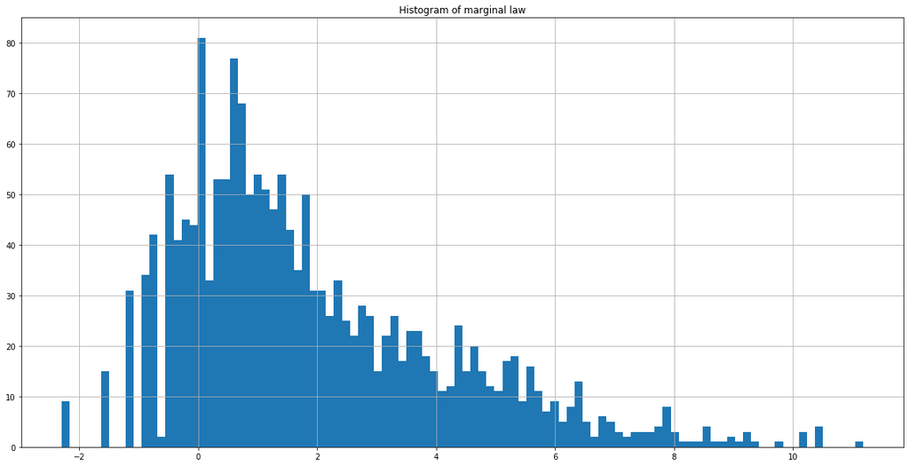

```python
plt.figure(figsize=(20,10))
plt.hist(df["IAS_brut"], 100)
plt.grid()
plt.title("Histogram of marginal law")
plt.show()
```

**The histogram is now more extensive. Transformation by the natural logarithm smoothed the data and made it more readable.**

## Analysis of the flu cycles

To analyze the periodicity of the flu episodes, we will display a periodogram, which estimates the power spectral density of a signal by taking the square of its Fourier transformation.

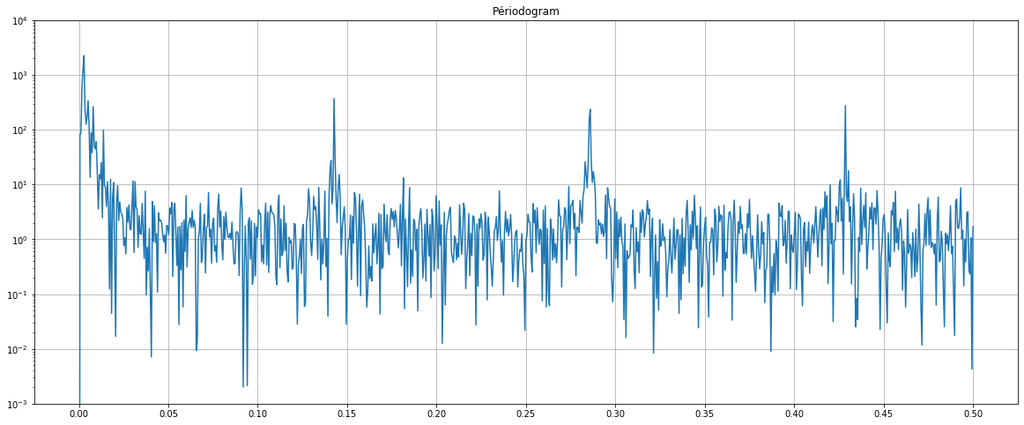

```python
from scipy import signal

plt.figure(figsize=(20,8))
f, Pxx_den = signal.periodogram(df["IAS_brut"])
plt.semilogy(f, Pxx_den)
plt.title("Périodogram")
plt.ylim([1e-3, 1e4])
plt.xticks(np.arange(0,0.55,0.05))
plt.grid()
plt.show()
```

**The periodogram shows at which frequencies appear peaks of influenza cases. We notice 4 main peaks (around 0, 0.14, 0.28, 0.43).**

We compute the exact frequency (in days) corresponding to the peaks:

```python
a = [np.argmax(Pxx_den)]
max_indexes = np.argpartition(Pxx_den, -10)[-10:]
b = np.extract(f[max_indexes] > 0.05, max_indexes)
index = sorted(np.concatenate((a,b)))
1/f[index]
```

```
array([350.4       ,   7.008     ,   3.49700599,   2.33288948])
```

**We note that the number of influenza cases is mainly cyclical every year (first peak: 350 days). We also note a cycle every week (second peak: 7 days). The frequency of the week may be explained by the facts that the patients certainly visit the doctor more on Monday than the weekend.**

## Remove a periodic trend

In order to better study some variations, we can remove periodic trends. Here, we will remove the one-year periodic trend from the data. By doing this, we will loose the data of the first year.

```python
df2 = df.copy()
df2["IAS_brut_diff_period"] = df2["IAS_brut"].diff(periods=365)
df2 = df2.dropna()
df2.head()
```

|  | period | IAS_brut | IAS_brut_diff_period |
| --- | --- | --- | --- |
| 365 | 2010-07-01 | 0.000000 | -0.530628 |
| 366 | 2010-07-02 | -0.105361 | -1.329136 |
| 367 | 2010-07-03 | -0.693147 | -1.435085 |
| 368 | 2010-07-04 | 0.182322 | -0.080043 |
| 369 | 2010-07-05 | -0.510826 | -3.164068 |

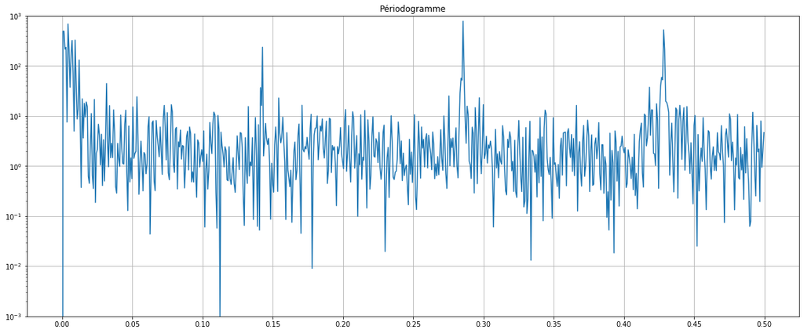

```python
plt.figure(figsize=(20,8))
f, Pxx_den = signal.periodogram(df2["IAS_brut_diff_period"])
plt.semilogy(f, Pxx_den)
plt.title("Périodogramme")
plt.ylim([1e-3, 1e3])
plt.xticks(np.arange(0,0.55,0.05))
plt.grid()
plt.show()
```

**By removing the annual trend the first peak is now reduced and become as important as the others.**

## Predict the tendency of the flu over a year

We will predict the number of cases of influenza for a year, based on periodic trends:

```python
# Save the dataframe for later work
df_initial = df.copy()
df.head()
```

|  | period | IAS_brut |
| --- | --- | --- |
| 0 | 2009-07-01 | 0.530628 |
| 1 | 2009-07-02 | 1.223775 |
| 2 | 2009-07-03 | 0.741937 |
| 3 | 2009-07-04 | 0.262364 |
| 4 | 2009-07-05 | 2.653242 |

To estimate the periodic tendy, for a fixed number of harmonics (n_harm), we will compute explanatory variables for the learning period: for each k = 1, 2, ... n_harm, we add two explanatory variables, xi,2k−1 = cos(ti · k · 2π / T ) and xi,2k = sin(ti · k · 2π / T ), where ti is the moment of time (we use whole numbers instead of dates) and T = 365.  
We first compute with n_harm = 10.

```python
n_harm = 10
for k in range(1, n_harm+1):
    df["cos_" + str(k)] = np.cos(df.index*k*2*np.pi/365)

for k in range(1, n_harm+1):
    df["sin_" + str(k)] = np.sin(df.index*k*2*np.pi/365)

df.head()
```

|  | period | IAS_brut | cos_1 | cos_2 | cos_3 | cos_4 | cos_5 | cos_6 | cos_7 | cos_8 | ... | sin_1 | sin_2 | sin_3 | sin_4 | sin_5 | sin_6 | sin_7 | sin_8 | sin_9 | sin_10 |
| --- | --- | --- | --- | --- | --- | --- | --- | --- | --- | --- | --- | --- | --- | --- | --- | --- | --- | --- | --- | --- | --- |
| 0 | 2009-07-01 | 0.530628 | 1.000000 | 1.000000 | 1.000000 | 1.000000 | 1.000000 | 1.000000 | 1.000000 | 1.000000 | ... | 0.000000 | 0.000000 | 0.000000 | 0.000000 | 0.000000 | 0.000000 | 0.000000 | 0.000000 | 0.000000 | 0.000000 |
| 1 | 2009-07-02 | 1.223775 | 0.999852 | 0.999407 | 0.998667 | 0.997630 | 0.996298 | 0.994671 | 0.992749 | 0.990532 | ... | 0.017213 | 0.034422 | 0.051620 | 0.068802 | 0.085965 | 0.103102 | 0.120208 | 0.137279 | 0.154309 | 0.171293 |
| 2 | 2009-07-03 | 0.741937 | 0.999407 | 0.997630 | 0.994671 | 0.990532 | 0.985220 | 0.978740 | 0.971100 | 0.962309 | ... | 0.034422 | 0.068802 | 0.103102 | 0.137279 | 0.171293 | 0.205104 | 0.238673 | 0.271958 | 0.304921 | 0.337523 |
| 3 | 2009-07-04 | 0.262364 | 0.998667 | 0.994671 | 0.988023 | 0.978740 | 0.966848 | 0.952378 | 0.935368 | 0.915864 | ... | 0.051620 | 0.103102 | 0.154309 | 0.205104 | 0.255353 | 0.304921 | 0.353676 | 0.401488 | 0.448229 | 0.493776 |
| 4 | 2009-07-05 | 2.653242 | 0.997630 | 0.990532 | 0.978740 | 0.962309 | 0.941317 | 0.915864 | 0.886071 | 0.852078 | ... | 0.068802 | 0.137279 | 0.205104 | 0.271958 | 0.337523 | 0.401488 | 0.463550 | 0.523416 | 0.580800 | 0.635432 |

5 rows × 22 columns

We divide the dataset into two, for the training period(2009-07 - 2013-03) and the testing period (2013-04 - 2014-04):

```python
df_train = df[(df["period"] >= "2009-07-01") & (df["period"] <= "2013-03-31")]
df_test = df[(df["period"] >= "2013-04-01") & (df["period"] <= "2014-04-17")]
X_train = df_train.drop(["period", "IAS_brut"], axis=1)
y_train = df_train["IAS_brut"]
X_test = df_test.drop(["period", "IAS_brut"], axis=1)
y_test = df_test["IAS_brut"]
```

We estimate the periodic tendency by regressing the training data with a linear regression:

```python
from sklearn.linear_model import LinearRegression

lr = LinearRegression()
lr = lr.fit(X_train, y_train)
y_pred = lr.predict(X_test)
```

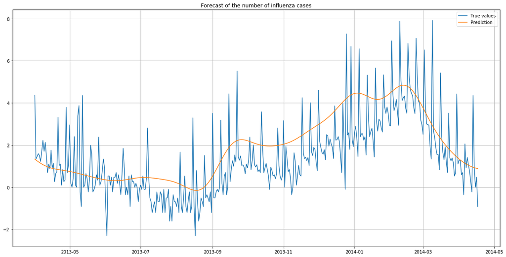

```python
plt.figure(figsize=(20,10))
plt.plot(df_test["period"], y_test, label="True values")
plt.plot(df_test["period"], y_pred, label="Prediction")
plt.grid()
plt.legend()
plt.title("Forecast of the number of influenza cases")
plt.show()
```

The predictions follow the same trend as the true values.  
However, the predictions are higher than the reality. There were likely to be more flu cases overall in the training years (in particular in 2013 as we have seen before) than in the year of predictions.

Let's display the data for all years of the dataset, to check it:

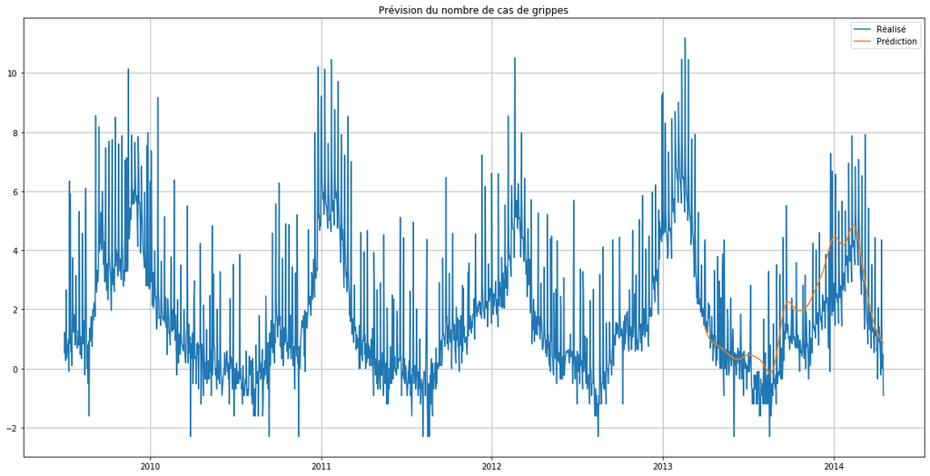

```python
plt.figure(figsize=(20,10))
plt.plot(df["period"], df["IAS_brut"], label="Réalisé")
plt.plot(df_test["period"], y_pred, label="Prédiction")
plt.grid()
plt.legend()
plt.title("Prévision du nombre de cas de grippes")
plt.show()
```

We compute the mean squared error and the residues:

```
Mean squared error: 1.869
```

[figure not shown]

```python
r_quad = sum((y_test - y_pred)**2)/len(y_test) #mean_squared_error(y_test, y_pred)
residus = y_test - y_pred
print("Mean squared error: {:.3f}".format(r_quad))
plt.figure(figsize=(20,10))
plt.plot(df_test["period"], residus)
plt.grid()
plt.title("Residues of the flu prediction")
plt.show()
```

**The residuals highlights that the deviations from the predictions were the largest between October and February (greatest deviation from the x-axis).**

We will compute the mean squared error for multiple n_harm parameter, in order to find the better one:

```python
r_quads = []

for n_harm in range(1,30):
    df = df_initial.copy()
    for k in range(1, n_harm+1):
        df["cos_" + str(k)] = np.cos(df.index*k*2*np.pi/365)
    for k in range(1, n_harm+1):
        df["sin_" + str(k)] = np.sin(df.index*k*2*np.pi/365)

    df_train = df[(df["period"] >= "2009-07-01") & (df["period"] <= "2013-03-31")]
    df_test = df[(df["period"] >= "2013-04-01") & (df["period"] <= "2014-04-17")]

    X_train = df_train.drop(["period", "IAS_brut"], axis=1)
    y_train = df_train["IAS_brut"]
    X_test = df_test.drop(["period", "IAS_brut"], axis=1)
    y_test = df_test["IAS_brut"]

    lr = LinearRegression()
    lr = lr.fit(X_train, y_train)
    y_pred = lr.predict(X_test)

    r_quads.append(sum((y_test - y_pred)**2)/len(y_test)) #mse
```

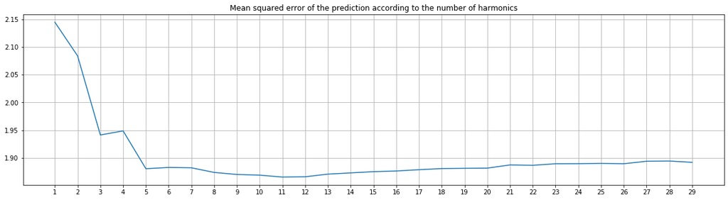

```python
plt.figure(figsize=(20,5))
plt.title("Mean squared error of the prediction according to the number of harmonics")
plt.plot(range(1,30), r_quads)
plt.xticks(range(1,30))
plt.grid()
plt.show()
```

The best (lowest) mean squared error is reached for **11 harmonics**.